# 推測統計(検定)

### 推測統計

少ない data から大きな集団の特徴を掴む

#### **母集団**と**標本**と**サンプリング** ↓ **推定・検定**

### 母集団と標本

- **母集団** → 情報を得たい対象全体
- **標本** → 母集団の一部

標本抽出のサンプリング

| **母集団** | **標本** |
| --- | --- |
| 母平均 : $\mu$ | 標本平均 : $\overline{X}$ |
| 母分散 : $\sigma^2$ | 標本分散 : $s^2$ |
| 母標準偏差 : $\sigma$ | 標本標準偏差 : $s$ |

## 仮説検定

ある仮説が偶然起こった事なのか **統計学的** に判断する方法

推定と同様に **標本分布** を元に考える  
↓  
仮説

#### 検定の考え方

> 1. 帰無仮説 : $H_0$
- 本当は **対立仮説** を言いたいが, 逆の仮説を立てる
> 2. 対立仮説 : $H_1$
- **本来自分が言いたい仮説**
> 3. 有意水準の決定(危険率, 棄却率)
- **よくある事と珍しい事の％**
  - 珍しい事が起これば **帰無仮説** が棄却 **対立仮説** を採択
  - よくある事が起これば **対立仮説** が棄却 **帰無仮説** を採択
  - 帰無仮説 $H_0$ : **正規分布の 95% の範囲に入るはず**
  - 対立仮説 $H_1$ : **正規分布の 5% の範囲に入るはず**

#### 上記の仮説 ( 検定 ) の仕方は **片側検定**

↓  
正規分布のグラフの片側の面積  
違う仮説の立て方て **両側検定** もある  
↓  
正規分布のグラフの両側の面積

$$標準化　=　\frac{\overline{X} - \mu}{\frac{\sigma}{\sqrt{n}}}$$

#### 仮定

近所の酒屋でお酒の量り売りをしているが, 最近お酒の量が減った気がする。１００g のお酒を 30日間買って量を測ったところ, 平均値が 98g, 標準偏差が 5g だった。

```r
xb <- 98
s <- 5
m <- 100
n <- 30

z <- (xb - m)/(s/sqrt(n))
z
```

```
[1] -2.19089
```

- $\overline{X}$ : 98 | $\mu$ : 100 | $\sigma$ : 5 | $\sqrt{n}$ : 30
  $$標準化　=　\frac{\overline{X} - \mu}{\frac{\sigma}{\sqrt{n}}}$$
- **pnorm( )** : 正規分布の面積を求める
  - マイナス記号の場合は片側検定の面積

```r
pnorm(-1.64, mean = 0, sd =1)
```

```
[1] 0.05050258
```

- **qnorm( )** : 上記の%となる点を見つけてくれる

```r
qnorm(0.05, mean = 0, sd = 1)
```

```
[1] -1.644854
```

## 推定と検定のまとめ

統計量が異なるとそれぞれ異なる **標本分布** が必要

母集団のどのような統計量を求めたいのか?sample数の大きさ etc ….  
↓

#### 上記のような基準を常に意識して区間推定をする

|  | sample数小 | sample数大 |
| --- | --- | --- |
| 母平均 | $t$分布 | 正規分布 ($t$分布) |
| 母分散 (母標準偏差) | $x^2$分布 (カイ二乗分布) | $x^2$分布 (カイ二乗分布) |
| 母比率 | $F$分布 | 正規分布 |

#### t分布を使用した検定

- 同時に区間推定もしてくれる
  - **95%の信頼区間** : 95.68908 ~ 99.91539

```r
x <- rnorm(30, mean = 98, sd =5)

t.test(x, conf.level = 0.95)
```

```
    One Sample t-test

data:  x
t = 94.659, df = 29, p-value < 2.2e-16
alternative hypothesis: true mean is not equal to 0
95 percent confidence interval:
 95.68908 99.91539
sample estimates:
mean of x
 97.80224
```

#### t分布検定

- 母平均が 100 の時に片側検定（下側）

```r
t.test(x, mu = 100, alternative = "less")
```

```
    One Sample t-test

data:  x
t = -2.1271, df = 29, p-value = 0.02102
alternative hypothesis: true mean is less than 100
95 percent confidence interval:
     -Inf 99.55779
sample estimates:
mean of x
 97.80224
```

#### 両側検定

```r
t.test(x, mu = 100)
```

```
    One Sample t-test

data:  x
t = -2.1271, df = 29, p-value = 0.04204
alternative hypothesis: true mean is not equal to 100
95 percent confidence interval:
 95.68908 99.91539
sample estimates:
mean of x
 97.80224
```

#### sample数の変化と区間の関係

- **r** = 推定区間
- **nn1** = sample数

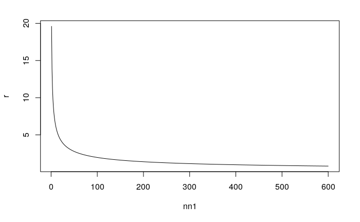

```r
nn1 <- c(1:600)
r <- 1.96*(10/sqrt(nn1))
plot(nn1, r, type = "l")
```

#### plot 拡大

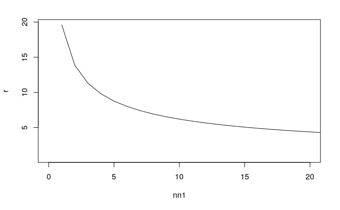

```r
plot(nn1, r, type = "l", xlim = c(0, 20))
```

ある程度母集団の標準偏差が推定される場合は  
sample数を求める為に区間を基準に決めることが出来る